# Simulador de escenarios fiscales

Instructivo para el usuario de simfi-rd

## Descargue el material

bit.ly/RD-microsimulacion-material

Contiene la app, los datos y el código del simulador.

## ¿Qué hace la app?

Permite **construir y comparar escenarios de reforma fiscal** para República Dominicana.

- Corre localmente en su computadora
- No requiere servidor Shiny
- Guía el trabajo en **seis pantallas** con botones *Anterior / Siguiente*

**Idea central**

> Un escenario = una decisión por pantalla.

> Cada decisión guardada es un **componente**.

## Antes de empezar

### 1. Instalar paquetes

Una sola vez, en la consola de R:

```r
install.packages(c(
  "shiny", "bslib", "DT", "plotly",
  "dplyr", "tidyr", "readxl", "sf",
  ...  # lista completa en el README
), dependencies = TRUE)
```

### 2. Abrir el proyecto

**File → Open Folder…** en Positron o RStudio (la carpeta completa, no solo `app.R`).

### 3. Lanzar

Abrir `app.R` y hacer clic en **Run App**.

Alternativa:

```r
shiny::runApp("app.R")
```

## Las seis pantallas

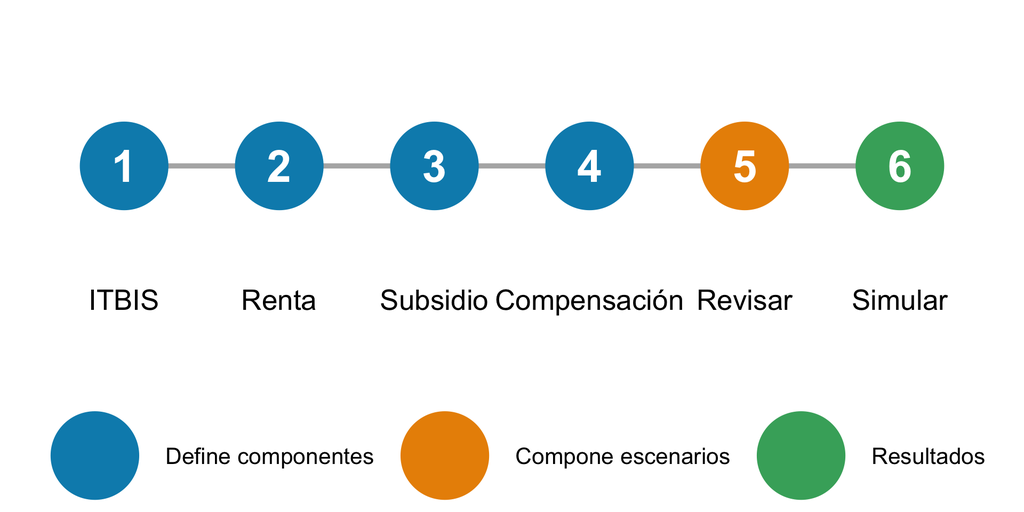

## 1 · ITBIS

- Tasas por producto
- Modificables por **grupo**, **subclase** o **variedad** individual
- Filtros de búsqueda por grupo, subclase y tasa

**Tip**

Al terminar, **guarde la decisión** como un componente de ITBIS.

## 2 · Renta y 3 · Subsidio

### Renta

Escala del ISR personal.

- Opcional
- Personalizable por **tramos** (límites y tasas)

### Subsidio

Subsidio eléctrico.

- Opcional
- Personalizable por **distribuidora** (bloques y tarifas)

## 4 · Compensación

Política de compensación post-reforma.

- Opcional
- Define **grupos** de hogares
- Elige **métodos de focalización**

## 5 · Revisar

- **Biblioteca** de componentes guardados, por instrumento
- **Compositor de escenarios**: elija un componente por instrumento
- Exportar / importar en **Excel**
- Botón **Nueva sesión** para empezar de cero (el estado se autoguarda)

## 6 · Simular

Ejecute los escenarios marcados y explore:

- Pobreza
- Desigualdad
- Incidencia
- Efecto fiscal

Escenarios ilimitados; se comparan **hasta cuatro** a la vez.

## Cómo se arma un escenario

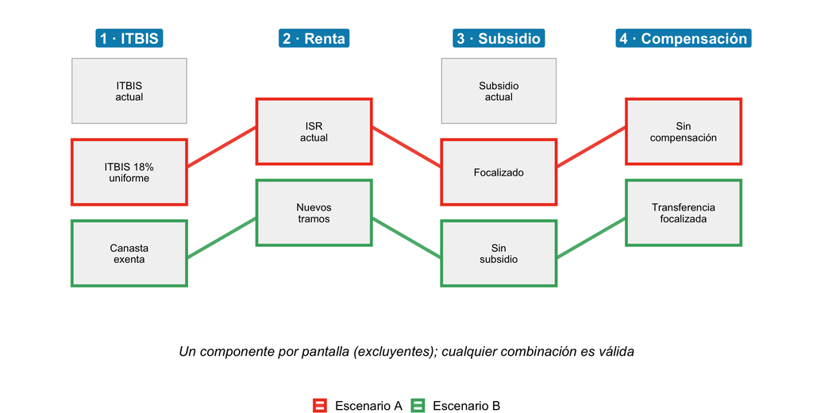

## Resumen

1. Cada pantalla (1 a 4) produce **componentes** guardados: sus decisiones de política.
2. En **Revisar** se elige **un componente por pantalla** para formar un escenario.
3. En **Simular** se ejecutan los escenarios y se comparan (hasta cuatro).

Más detalles y video de instrucciones: `README.md`.